## Goal

This somewhat technical exercise is concerned with getting more familiar with the hyperparameters of xgboost. The focus in this exercise is therefore **not so much on optimal modelling strategy** but on showcasting features of the xgboost algorithm and on their **usage**.

The first goal in this notebook is to understand how to parallelize xgboost to reduce training time by utilizing multiple cores. The second goal is to understand how one can include monotonicity and interaction constraints into the model and visualize their effects. We will also discuss what those constraints actually entail.

## Useful resources

- [mlr3 book chapter on parallelization](https://mlr3book.mlr-org.com/technical.html)
- [StatQuest video series on Xgboost](https://www.youtube.com/watch?v=OtD8wVaFm6E)

# German Credit Dataset

As in previous exercises, we use the German credit dataset of Prof. Dr. Hans Hoffman of the University of Hamburg in 1994. By using XGBoost, we want to classify people as a good or bad credit risk based on 20 personal, demographic and financial features. The dataset is available at the UCI repository as [Statlog (German Credit Data) Data Set](https://archive.ics.uci.edu/ml/datasets/Statlog+%28German+Credit+Data%29).

# Exercises

## Reducing training time

**Recap**

In mlr3 we distinguish between *explicit* and *implicit* parallelization. The former is done by `mlr3` using the R package `future` and can be used to e.g. parallelize resampling, benchmarking, tuning or prediction. The latter is done by calling external code (i.e. code from a CRAN package like xgboost) which runs in parallel. In this usecase we are referring to the implicit parallelization from xgboost if not stated otherwise. Note that using implicit and explicit parallelization simultaneously can lead to conflicts and the former is thereby disabled by default.

**Note**: The focus here is on *showing the features* of the learner and not on optimal methodology.

**Hint 1:**

Use the function `bench::mark(..., check = FALSE)` to compare the timings. Instantiate the resampling before, to ensure that the same train-test split. The pipeops `po("encode")` and `po("removeconstants")` can be helpful for the preprocessing.

**Hint 2:**

```r
  library(mlr3verse)

  task = tsk(...)
  task = (po(...) %>>% po(...))$train(task)[[1L]]

  learner = lrn(...)
  learner_parallel = lrn(...)

  resampling = rsmp("holdout")$instantiate(task)

  timing_10 = bench::mark(
    resample(...),
    resample(...),
    check = FALSE
  )

  timing_10

  learner$param_set$values$nrounds = 1000
  learner_parallel$param_set$values$nrounds = 1000


  timing_1000 = bench::mark(
    resample(...),
    resample(...),
    check = FALSE
  )

  timing_1000
```

### Solution:

**Click me:**

```r
library(mlr3verse)

task = tsk("german_credit")
task$positive = "good"
task = (po("encode", method = "one-hot") %>>% po("removeconstants"))$train(task)[[1L]]

learner = lrn("classif.xgboost", nrounds = 10)
learner_parallel = lrn("classif.xgboost", nthread = 4, nrounds = 10)

resampling = rsmp("holdout")$instantiate(task)

timing_10 = bench::mark(
  resample(task, learner, resampling),
  resample(task, learner_parallel, resampling),
  check = FALSE
)

timing_10
```

```
## # A tibble: 2 × 6
##   expression                                        min   median `itr/sec` mem_alloc `gc/sec`
##   <bch:expr>                                   <bch:tm> <bch:tm>     <dbl> <bch:byt>    <dbl>
## 1 resample(task, learner, resampling)             131ms    134ms      7.34   79.72MB     2.45
## 2 resample(task, learner_parallel, resampling)    130ms    134ms      7.49    6.12MB     2.50
```

```r
learner$param_set$values$nrounds = 1000
learner_parallel$param_set$values$nrounds = 1000


timing_1000 = bench::mark(
  resample(task, learner, resampling),
  resample(task, learner_parallel, resampling),
  check = FALSE
)

timing_1000
```

```
## # A tibble: 2 × 6
##   expression                                        min   median `itr/sec` mem_alloc `gc/sec`
##   <bch:expr>                                   <bch:tm> <bch:tm>     <dbl> <bch:byt>    <dbl>
## 1 resample(task, learner, resampling)             1.95s    1.95s     0.512    7.22MB    0
## 2 resample(task, learner_parallel, resampling)    1.19s    1.19s     0.838    7.11MB    0.838
```

The training time of xgboost can be simplified as $\text{startup} + \text{costs_per_iteration} \times \text{iters}$. When parallelizing, the time is saved in each iteration where a tree is fit. With only few iterations, the effect of saving time per iteration is relatively small compared to the startup costs. Therefore, the relative difference is much lower in the first, compared to the second comparison.

The parallel implementation is however still not four times as fast. One reason is that only parts of the algorithm can be parallelized (more on that in the next exercise).

## Parallelizing what?

In the exercise we have seen how to speed up training time of xgboost using parallelization, without thinking **what** is parallelized. Using your knowledge of gradient boosting to answer what part of the gradient boosting algorithm can be parallelized. Specifically address whether gradient boosting allows for parallelizing the creation of its individual trees.

**Hint 1:**

How are the individual base learners (usually trees) in xgboost related? Think about the difference between boosting and bagging.

**Hint 2:**

In gradient boosting, tree takes the errors of the previous trees into account. Can this be parallelized?

### Solution:

**Click me:**

In gradient boosting algorithms each base learner is trained on data, taking into account the previous base learner’s (usually a tree) success, which means that the creation of trees cannot be parallelized, as the algorithm can only start with the n-th tree, when the (n-1)-th tree is fit.

This has to be distinguished from bagging (like in a random forest) where the trees are built independently and which could therefore be parallelized. (Note that the actual `xgboost` implementation even allows for the creation of parallel trees, which results in a boosted random forest, see the experimental parameter `num_parallel_tree`.)

In xgboost, the creation of splits for a new node within a tree can be parallelized, as the optimal splits for different features can be found in parallel.

## Monotonicity of feature effects

**Recap**

A Partial Dependency Plot (PDP) is a model agnostic way to visualize the marginal effect of a feature on the prediction. You can read more about it on Christoph Molnar’s [excellent book](https://christophm.github.io/interpretable-ml-book/pdp.html).

You reason that longer credit durations should lead to a higher credit risk. Include this assumption in your xgboost model (100 rounds) and train it on a standard holdout split.

Afterwards create a create a partial dependency plot for the test data using the `iml` R package. For that you need to predict probabilities.

**Hint 1:**

The parameter `monotone_constraints` might be interesting. It has to be a vector equal to the length of the features, where $+1$ indicates a monotonly positive and $-1$ a monotonly negative effect, $0$ indicates no restriction. For creating the PDP, use the `iml` R package. There is a [chapter](https://mlr3book.mlr-org.com/interpretation.html) in the mlr3book that can be helpful

**Hint 2:**

```r
  library(iml)

  constraints_mon = (task$feature_names == ...) * -1

  learner = lrn(...)

  ids = partition(task)

  learner$train(...)

  model = Predictor$new(
    learner,
    data = task$data(ids$test, cols = task$feature_names),
    y = task$data(ids$test, cols = task$target_names)[[1L]]
  )

  effect = FeatureEffect$new(model, method = ..., feature = ...)
  plot(effect)
```

### Solution:

**Click me:**

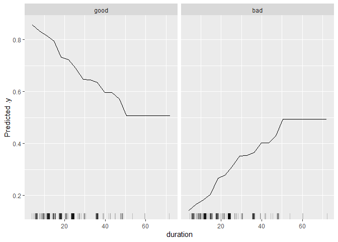

```r
library(iml)

constraints_mon = (task$feature_names == "duration") * -1

learner = lrn("classif.xgboost", monotone_constraints = constraints_mon, nrounds = 100,
  predict_type = "prob"
)

ids = partition(task)

learner$train(task, ids$train)

model = Predictor$new(
  learner,
  data = task$data(ids$test, cols = task$feature_names),
  y = task$data(ids$test, cols = task$target_names)[[1L]]
)

effect = FeatureEffect$new(model, method = "pdp", feature = "duration")
plot(effect)
```

Note that for two-class classification problems it is enough to consider only one plot, as they contain the same information. The plot confirms that we we indeed constrained the marginal effect of duration to be negative.

## Interaction of features

**Recap**

The decision tree is a powerful tool to discover interaction among independent variables (features). Variables that appear together in a traversal path are interacting with one another, since the condition of a child node is predicated on the condition of the parent node.

When two features appear in the same tree they are said to be interacting. By default, xgboost does not restrict which features can appear in the same tree, so all (higher order) interactions between features are in principle possible.

You are interested in the interaction between age and duration. Restrict your model so that those two features can only interact with each other and repeat the experiment from the previous exercise.

Afterwards visualize the results using a 2d PDP plot.

**Hint 1:**

The parameter `interaction_constraints` might be interesting. Read the documentation and don’t forget to use 0-indexing. When using `FeatureEffect` from `iml`, set `feature = c("duration", "age")`

**Hint 2:**

```r
  fn = task$feature_names

  constraints_int = list(c(which(fn == ...), which(fn == ...)) - 1) # 0 indexing

  learner = lrn(...)

  ids = partition(task)

  learner$train(task, ids$train)

  model = Predictor$new(learner, data = task$data(ids$test, cols = task$feature_names),
    y = task$data(ids$test, cols = task$target_names)[[1L]])

  effect = FeatureEffect$new(model, feature = c(..., ...), method = ...)
  plot(effect)
```

### Solution:

**Click me:**

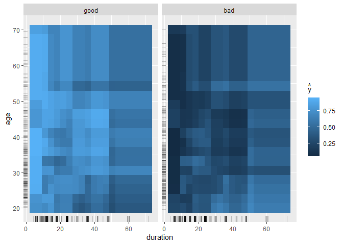

```r
fn = task$feature_names

constraints_int = list(c(which(fn == "duration"), which(fn == "age")) - 1) # 0 indexing

learner = lrn("classif.xgboost", interaction_constraints = constraints_int, nrounds = 100,
  predict_type = "prob"
)

ids = partition(task)

learner$train(task, ids$train)

model = Predictor$new(learner, data = task$data(ids$test, cols = task$feature_names),
  y = task$data(ids$test, cols = task$target_names)[[1L]])

effect = FeatureEffect$new(model, feature = c("duration", "age"), method = "pdp")
plot(effect)
```

## Monotonicity, Interaction and Correlation

In the previous two exercises we have shown how one can **technically** restrict the effect directions and effect interactions between variables. Now we will consider what we this actually entails.

**Hint 1:**

Think about correlations between the features.

**Hint 2:**

When comparing people with different values of a variables, are they then otherwise identical?

### Solution:

**Click me:**

In case all the features are independent, the answer is **yes**, because we are then making a *ceteris paribus* comparison. Otherwise, the difference in the duration might also entail a difference in other features, in which case the answer is **no**. This has to be taken into account when interpreting PDP plots.

## Bonus exercise: Parallel prediction

Earlier we have parallelized the **training** of a learner. Now we also want to parallelize the **prediction** phase.

Compare the timings of training an xgboost model on a default holdout split with 100 rounds with and without parallel prediction. Explain the results and answer whether it makes sense in this case to parallelize the prediction.

**Hint 1:**

`help(Learner)` has information about the field `parallel_predict`.

**Hint 2:**

```r
  library(future)

  future::plan(future::multisession())
  learner = lrn()
  learner_parallel = lrn()

  resampling = rsmp("holdout")$instantiate(task)

  timing = bench::mark(
      ...,
      ...,
    check = FALSE
  )
```

### Solution:

**Click me:**

```r
  library(future)

  future::plan(future::multisession())
  learner = lrn("classif.xgboost", nrounds = 100)
  learner_parallel = lrn("classif.xgboost", nrounds = 100, parallel_predict = TRUE)

  resampling = rsmp("holdout")$instantiate(task)

  timing = bench::mark(
  resample(task, learner, resampling),
  resample(task, learner_parallel, resampling),
  check = FALSE
  )
  timing
  ## # A tibble: 2 × 6
  ##   expression                                        min   median `itr/sec` mem_alloc `gc/sec`
  ##   <bch:expr>                                   <bch:tm> <bch:tm>     <dbl> <bch:byt>    <dbl>
  ## 1 resample(task, learner, resampling)             421ms    422ms      2.37    3.97MB        0
  ## 2 resample(task, learner_parallel, resampling)    434ms    440ms      2.27    3.86MB        0
```

In this case it does not really make sense to parallelize the prediction, as the number of observations is too low to make an actual difference when taking the startup and communication costs between the cores into account. Parallelizing predictions is either useful when each individual prediction takes long, or when many predictions must be made.

# Summary

In this exercise we learned how to parallelize the xgboost training and understood what can be parallelized.

Using monotonicity- and interaction constraints we have also discovered two methods to include prior knowledge into our model, which we visualized using the iml R package. We have also understood that the correlation between features has to be taken into account when interpreting the results.

Finally, we have learned how one can parallelize the prediction phase.